# PQHS 431 Project - Wu

# 1 Environment Set-up:

Below are the various packages that were imported to conduct this project.

```r
# source("Love-boost.R")
# library(Hmisc); library(Epi); library(vcd)
library(knitr); library(rmdformats); library(rmarkdown)
library(simputation); library(skimr); library(magrittr)
library(broom); library(GGally); library(car)
library(tidyverse)
## Global options
options(max.print="75")
opts_chunk$set(comment=NA,
               message=FALSE,
               warning=FALSE)
opts_knit$set(width=75)
## Skim options (leave out histograms)
skimr::skim_with(numeric = list(hist = NULL),
                 integer = list(hist = NULL))
```

# 2 Import Dataset:

Below are the steps that imported the dataset and converted all column names to Upper-Case.

```r
load('C:/Users/jwu41/Desktop/School/AU2018/PQHS 431/Project/NSDUH_2016.RData')
```

```r
for( i in 1:ncol(PUF2016_022818))
  {
   colnames(PUF2016_022818)[i] <- toupper(colnames(PUF2016_022818)[i])
  }
```

# 3 Cleaning the Dataset:

## 3.1 Merging all Alcohol Consumption Variables Into One:

Due to the nature of how this question was asked, respondents only answered one of the consumption time frames depending on which they were most comfortable with. To prevent working on multiple datasets, we merged all the variables into the “year” time frame. Days of Alcohol consumption per week were multiplied by 52 and Days of Alcohol Consumption per Month were multiplied by 12. First we subset the dataset by their respective time intervals and create new variables to conform with the “year” time frame. We then rbind all three datasets into one, since they all have the same variable names and same number of variables.

```r
nsduh2016 <- PUF2016_022818

nsduh2016 <- nsduh2016 %>%
    mutate(newALYR = ALDAYPYR)
nsduh2016 <- nsduh2016 %>%
    mutate(newALMO = ALDAYPMO)
nsduh2016 <- nsduh2016 %>%
    mutate(newALWK = ALDAYPWK)

nsduh2016$newALYR <- as.numeric(nsduh2016$newALYR)
nsduh2016$newALMO <- as.numeric(nsduh2016$newALMO)
nsduh2016$newALWK <- as.numeric(nsduh2016$newALWK)

nsduh2016YEAR <- subset(nsduh2016, newALYR >= 1 & newALYR <= 365)
nsduh2016MO <- subset(nsduh2016, newALMO >= 1 & newALMO <= 31)
nsduh2016WEEK <- subset(nsduh2016, newALWK >= 1 & newALWK <= 7)

nsduh2016WEEK$Alcohol <- nsduh2016WEEK$newALWK*52
nsduh2016MO$Alcohol <- nsduh2016MO$newALMO*12
nsduh2016YEAR$Alcohol <- nsduh2016YEAR$newALYR

nsduh2016_temp <- rbind(nsduh2016WEEK, nsduh2016MO, nsduh2016YEAR)
nsduh2016_temp <- nsduh2016_temp %>%
  select(Alcohol, IRSEX, IREDUHIGHST2, ADWRDST, ADWRAGE)

summary(nsduh2016_temp)
```

```
    Alcohol           IRSEX        IREDUHIGHST2       ADWRDST
 Min.   :  1.00   Min.   :1.000   Min.   : 1.000   Min.   : 1.00
 1st Qu.: 12.00   1st Qu.:1.000   1st Qu.: 8.000   1st Qu.:99.00
 Median : 52.00   Median :2.000   Median : 9.000   Median :99.00
 Mean   : 83.34   Mean   :1.522   Mean   : 8.863   Mean   :77.29
 3rd Qu.:120.00   3rd Qu.:2.000   3rd Qu.:11.000   3rd Qu.:99.00
 Max.   :372.00   Max.   :2.000   Max.   :11.000   Max.   :99.00
    ADWRAGE
 Min.   :  1.0
 1st Qu.:999.0
 Median :999.0
 Mean   :823.2
 3rd Qu.:999.0
 Max.   :999.0
```

## 3.2 Collapsing Categories for Education:

The Education Levels (`IREDUHIGHST2`) were collapsed due to low counts if the variable was left as is. All Education levels up to Not Completing High School were combined into one group “Did Not Complete High School”. All other Education levels were left as they were originally for a total of 5 groups (Did not complete high school, high school, did not complete college, associate’s degree, and bachelor’s and up) were created for the new variable `newEdu`.

```r
nsduh2016_temp$IREDUHIGHST2 <- as.character(nsduh2016_temp$IREDUHIGHST2)


nsduh2016_temp <- nsduh2016_temp %>%
    mutate(newEdu = fct_recode(IREDUHIGHST2,
                                 "DNCHS" = "1",
                                 "DNCHS" = "2",
                                 "DNCHS" = "3",
                                 "DNCHS" = "4",
                                 "DNCHS" = "5",
                                 "DNCHS" = "6",
                                 "DNCHS" = "7",
                                 "HS" = "8",
                                 "DNCC" = "9",
                                 "AD" = "10",
                                 "BAU" = "11"))

nsduh2016_temp %>% count(IREDUHIGHST2, newEdu)
```

| IREDUHIGHST2 | newEdu | n |
| --- | --- | --- |
| 1 | DNCHS | 173 |
| 10 | AD | 3021 |
| 11 | BAU | 9365 |
| 2 | DNCHS | 177 |
| 3 | DNCHS | 249 |
| 4 | DNCHS | 539 |
| 5 | DNCHS | 1006 |
| 6 | DNCHS | 1259 |
| 7 | DNCHS | 2178 |
| 8 | HS | 7360 |

[output cut: 1 more lines]

```r
nsduh2016_temp$newEdu <- as.factor(nsduh2016_temp$newEdu)
```

## 3.3 Subset the Data further to only contain those who responded to “Age when worst period of time started” and “Severity of Emotional Distress during the last two weeks”:

These two variables were quantitative variables. In the codebook however, they did not only contain the valid responses; there were others such as: DONT KNOW, REFUSED, BLANK, and LEGITIMATE SKIP. These variables were removed from the `nsduh2016_temp` dataset.

```r
nsduh2016_temp$ADWRDST <- as.character(nsduh2016_temp$ADWRDST)
nsduh2016_temp$ADWRAGE <- as.character(nsduh2016_temp$ADWRAGE)


nsduh2016_temp <- subset(nsduh2016_temp, !(ADWRAGE %in% c("985","994","997","998","999")))
nsduh2016_temp <- subset(nsduh2016_temp, !(ADWRDST %in% c("94","97","98","99")))

nsduh2016_temp$ADWRAGE <- as.numeric(nsduh2016_temp$ADWRAGE)

summary(nsduh2016_temp)
```

```
    Alcohol           IRSEX      IREDUHIGHST2         ADWRDST
 Min.   :  1.00   Min.   :1.00   Length:6024        Length:6024
 1st Qu.: 12.00   1st Qu.:1.00   Class :character   Class :character
 Median : 52.00   Median :2.00   Mode  :character   Mode  :character
 Mean   : 86.14   Mean   :1.64
 3rd Qu.:144.00   3rd Qu.:2.00
 Max.   :372.00   Max.   :2.00
    ADWRAGE        newEdu
 Min.   : 1.00   DNCHS: 418
 1st Qu.:18.00   AD   : 627
 Median :22.00   BAU  :1905
 Mean   :25.55   HS   :1237
 3rd Qu.:31.00   DNCC :1837
 Max.   :85.00
```

## 3.4 Changing ADWRDST (Severity of Emotional Stress) from character to factor and Recategorization of IRSEX:

A new variable was created to make Severity of Emotional Stress more easily understood. The same was done for Sex of the respondent.

```r
nsduh2016_temp$ADWRDST <- as.character(nsduh2016_temp$ADWRDST)

nsduh2016_temp <- nsduh2016_temp %>%
    mutate(Severity = fct_recode(ADWRDST,
                                 "Mild" = "1",
                                 "Moderate" = "2",
                                 "Severe" = "3",
                                 "Very Severe" = "4"))

nsduh2016_temp %>% count(ADWRDST, Severity)
```

| ADWRDST | Severity | n |
| --- | --- | --- |
| 1 | Mild | 369 |
| 2 | Moderate | 2343 |
| 3 | Severe | 2288 |
| 4 | Very Severe | 1024 |

```r
nsduh2016_temp$Severity <- as.factor(nsduh2016_temp$Severity)
```

```r
nsduh2016_temp$IRSEX <- as.character(nsduh2016_temp$IRSEX)

nsduh2016_temp <- nsduh2016_temp %>%
    mutate(Sex = fct_recode(IRSEX,
                                 "Male" = "1",
                                 "Female" = "2"))

nsduh2016_temp %>% count(Sex, IRSEX)
```

| Sex | IRSEX | n |
| --- | --- | --- |
| Male | 1 | 2169 |
| Female | 2 | 3855 |

```r
nsduh2016_temp$Sex <- as.factor(nsduh2016_temp$Sex)
```

## 3.5 Cleaning Up the Data for our final Dataset:

The final dataset will contain `Alcohol`, `Sex`, `newEdu`, `ADWRAGE`, and `Severity`.

```r
nsduh2016_final <- nsduh2016_temp %>%
  select (Alcohol, Sex, newEdu, ADWRAGE, Severity)

summary(nsduh2016_final)
```

```
    Alcohol           Sex         newEdu        ADWRAGE
 Min.   :  1.00   Male  :2169   DNCHS: 418   Min.   : 1.00
 1st Qu.: 12.00   Female:3855   AD   : 627   1st Qu.:18.00
 Median : 52.00                 BAU  :1905   Median :22.00
 Mean   : 86.14                 HS   :1237   Mean   :25.55
 3rd Qu.:144.00                 DNCC :1837   3rd Qu.:31.00
 Max.   :372.00                              Max.   :85.00
        Severity
 Mild       : 369
 Moderate   :2343
 Severe     :2288
 Very Severe:1024
```

## 3.6 Creation of Subj_Id:

Subj_ID was created to simplify the process creating the training and test samples.

```r
nsduh2016_final <- tibble::rowid_to_column(nsduh2016_final, "subj_id")

nsduh2016_final
```

| subj_id | Alcohol | Sex | newEdu | ADWRAGE | Severity |
| --- | --- | --- | --- | --- | --- |
| 1 | 104 | Male | DNCHS | 30 | Severe |
| 2 | 156 | Male | BAU | 20 | Very Severe |
| 3 | 52 | Male | DNCC | 34 | Severe |
| 4 | 156 | Female | BAU | 32 | Moderate |
| 5 | 52 | Male | DNCHS | 18 | Very Severe |
| 6 | 156 | Female | BAU | 19 | Very Severe |
| 7 | 156 | Female | BAU | 31 | Severe |
| 8 | 364 | Female | BAU | 51 | Mild |
| 9 | 104 | Female | BAU | 20 | Severe |
| 10 | 156 | Female | BAU | 23 | Moderate |

[output cut: 65 more lines]

```r
nsduh2016_final$subj_id <- as.character(nsduh2016_final$"subj_id")

nsduh2016_final
```

| subj_id | Alcohol | Sex | newEdu | ADWRAGE | Severity |
| --- | --- | --- | --- | --- | --- |
| 1 | 104 | Male | DNCHS | 30 | Severe |
| 2 | 156 | Male | BAU | 20 | Very Severe |
| 3 | 52 | Male | DNCC | 34 | Severe |
| 4 | 156 | Female | BAU | 32 | Moderate |
| 5 | 52 | Male | DNCHS | 18 | Very Severe |
| 6 | 156 | Female | BAU | 19 | Very Severe |
| 7 | 156 | Female | BAU | 31 | Severe |
| 8 | 364 | Female | BAU | 51 | Mild |
| 9 | 104 | Female | BAU | 20 | Severe |
| 10 | 156 | Female | BAU | 23 | Moderate |

[output cut: 65 more lines]

# 4 Codebook for Final Test Table:

The final dataset will contain 5 variables. *`Alcohol` observations that are greater than 365 originated from multiplication of either the days per month or days per week drinking response variables. For example, if someone drank 31 days a month, to convert that to days per year would result in 372, or 31x12.

[output not shown]

# 5 Step 1. Dealing with Missing Values:

First, we will check if there are any missing values in any observations.

```r
colSums(is.na(nsduh2016_final))
```

```
 subj_id  Alcohol      Sex   newEdu  ADWRAGE Severity
       0        0        0        0        0        0
```

As seen above, there are no observations with missing values. No Imputation or Deletion necessary.

# 6 Step 2. Identify Training and Test Samples

```r
set.seed(431001)

sp2_training <- nsduh2016_final %>% sample_frac(.75)
sp2_test <- anti_join(nsduh2016_final, sp2_training, by = "subj_id")

dim(sp2_training)
```

```
[1] 4518    6
```

```r
dim(sp2_test)
```

```
[1] 1506    6
```

# 7 Step 3. Summarize the Outcome and the Predictors:

## 7.1 Visualizing the Outcome Distribution:

Looking at the Histograms and QQ-Plots below, it is clear that our outcome data is not Normal; There appears to be a right skew.

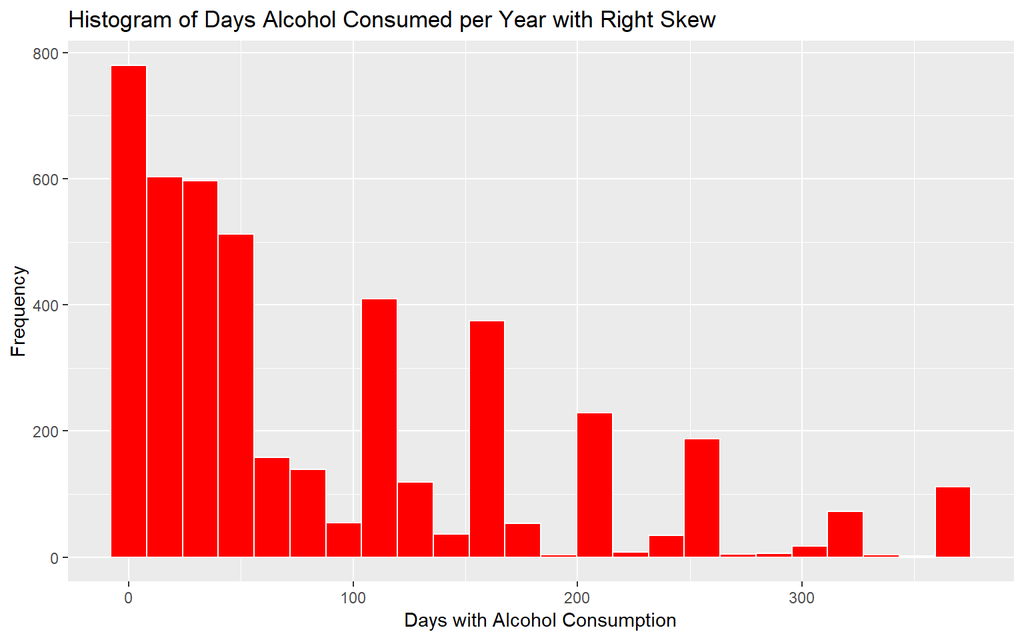

```r
bw <- 2 * IQR(sp2_training$Alcohol) / length(sp2_training$Alcohol)^(1/3)
hist3 <- ggplot(data = sp2_training, aes(x = Alcohol)) + geom_histogram(binwidth = bw, color  = "white", fill = "red")+labs(title = "Histogram of Days Alcohol Consumed per Year with Right Skew", x = "Days with Alcohol Consumption", y = "Frequency")

hist3
```

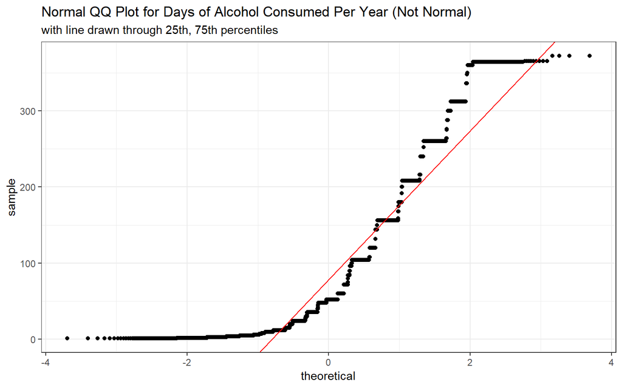

```r
y <- quantile(sp2_training$Alcohol, c(0.25, 0.75))
x <- qnorm(c(0.25, 0.75))
slope <- diff(y)/diff(x)
int <- y[1L] - slope*x[1L]

qq3 <- ggplot(sp2_training, aes(sample = Alcohol)) + geom_point(stat = "qq") + theme_bw() + labs(title = "Normal QQ Plot for Days of Alcohol Consumed Per Year (Not Normal)", subtitle = "with line drawn through 25th, 75th percentiles") + geom_qq(alpha = 0.5) + geom_abline(slope = slope, intercept = int, col = "red")

qq3
```

## 7.2 Numerical Summary of Outcome:

Using Numerical Summaries as well, we can see that there are differences between the means and medians of our outcome variables. The summaries also indicate that there is a right skew in our data.

```r
mosaic::favstats(~Alcohol, data = sp2_training)
```

|  | min | Q1 | median | Q3 | max | mean | sd | n | missing |
| --- | --- | --- | --- | --- | --- | --- | --- | --- | --- |
|  | 1 | 12 | 52 | 144 | 372 | 86.29216 | 91.61245 | 4518 | 0 |

## 7.3 Numerical Summary of the Predictors:

As previously checked, there are no missing data from any of the predictors. There are three categorical predictors and one quantitative predictor.

```r
sp2_training %>% select(Sex, newEdu, ADWRAGE, Severity) %>% skim()
```

```
Skim summary statistics
 n obs: 4518
 n variables: 4

-- Variable type:factor ------------------------------------------------------------------------------------------------
 variable missing complete    n n_unique
   newEdu       0     4518 4518        5
 Severity       0     4518 4518        4
      Sex       0     4518 4518        2
                               top_counts ordered
   BAU: 1453, DNC: 1348, HS: 922, AD: 466   FALSE
 Mod: 1776, Sev: 1695, Ver: 769, Mil: 278   FALSE
              Fem: 2881, Mal: 1637, NA: 0   FALSE

-- Variable type:numeric -----------------------------------------------------------------------------------------------
 variable missing complete    n  mean    sd p0 p25 p50 p75 p100
  ADWRAGE       0     4518 4518 25.54 11.51  1  18  22  31   85
```

# 8 Step 4. Scatterplot Matrix and Transformation Checking:

## 8.1 Scatterplot Matrix:

Below are scatterplots matrices of the main outcome variable with two matrices. The first matrix contains the predictors `Sex` and `Severity`, and the second matrix contains the predictors `ADWRAGE` and `newEdu`. If we look at `Alcohol` against the predictors, it would seem that there are differences in Alcohol consumption by `Sex`, but not so much for `Severity`. There seems to be a low correlation between `ADWRAGE` and `Alcohol`. Like with `Severity`, there do not seem to be much difference in Alcohol consumption by `newEdu`.

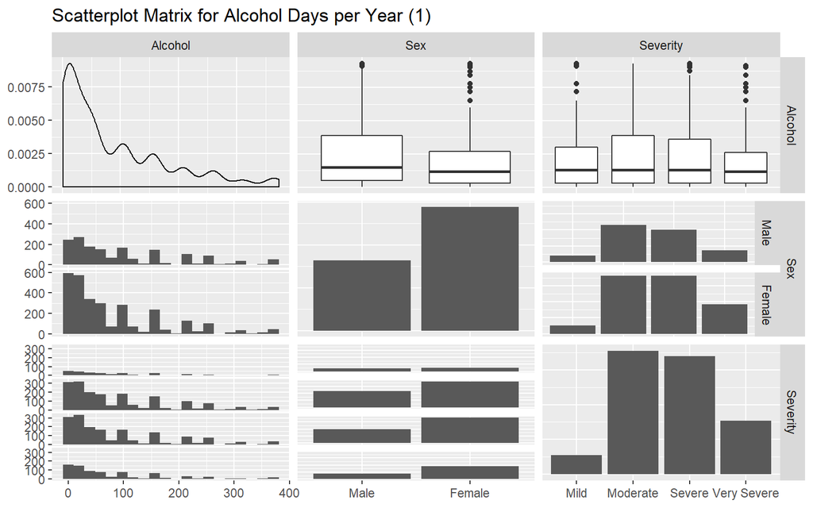

```r
sp2_training %>%
  select(Alcohol, Sex, Severity) %>%
  ggpairs(., title = "Scatterplot Matrix for Alcohol Days per Year (1)",
          lower = list(combo = wrap("facethist", bins = 20)))
```

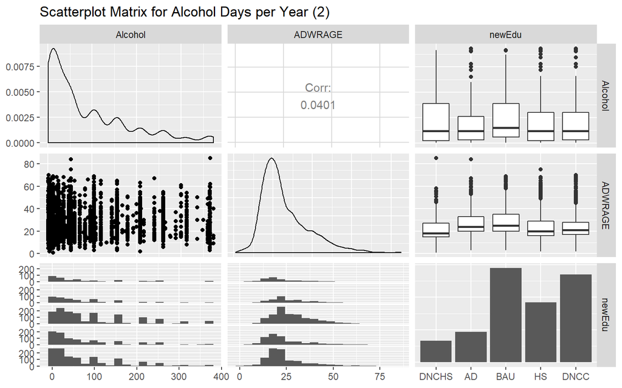

```r
sp2_training %>%
  select(Alcohol, ADWRAGE, newEdu) %>%
  ggpairs(., title = "Scatterplot Matrix for Alcohol Days per Year (2)",
          lower = list(combo = wrap("facethist", bins = 20)))
```

## 8.2 Collinearity Checking:

None of the predictors show any substantial collinearity. None of the Generalized VIF exceed 5, at which point we would have concerns. As shown below, none of the GVIF’s exceed 1.05.

```r
model1 <- lm(Alcohol~Sex + Severity + newEdu + ADWRAGE, data = sp2_training)

vif(model1)
```

```
             GVIF Df GVIF^(1/(2*Df))
Sex      1.013845  1        1.006899
Severity 1.013854  3        1.002296
newEdu   1.041589  4        1.005106
ADWRAGE  1.037210  1        1.018435
```

## 8.3 `boxCox` function to assess need for transformation of our outcome:

From the results shown below, our transformation parameters seem to be closest to 0. Therefore, we will be conducting a log-transformation.

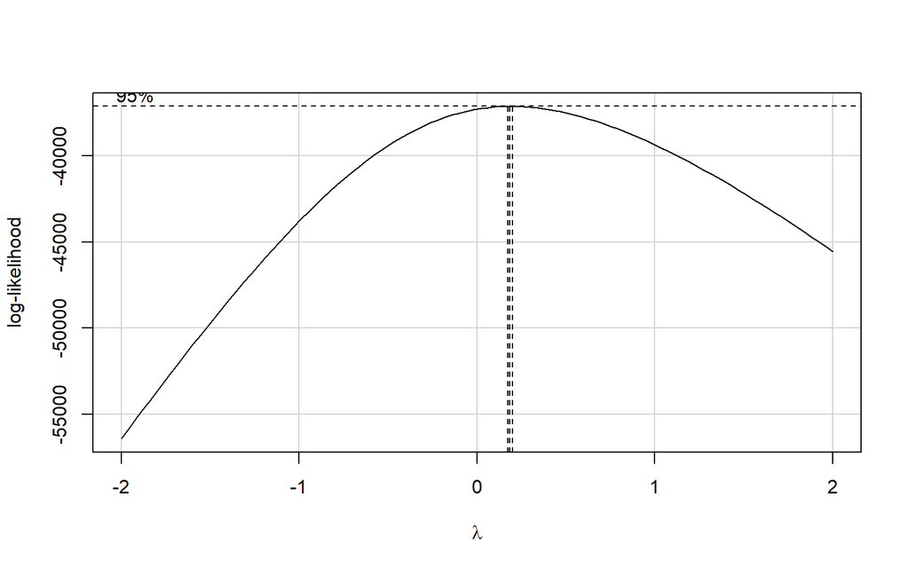

```r
boxCox(model1)
```

```r
powerTransform(model1)
```

```
Estimated transformation parameter
      Y1
0.190226
```

```r
model1_tf <- lm(log(Alcohol) ~ Sex + Severity + newEdu + ADWRAGE, data = sp2_training)
```

# 9 Step 5. Kitchen Sink Model Assessment:

Below is the Kitchen Sink Linear Regression Model. Our Kitchen sink models have already been created after the transformations in the previous step.

## 9.1 Summarizing the Kitchen Sink model:

```r
summary(model1_tf)
```

```
Call:
lm(formula = log(Alcohol) ~ Sex + Severity + newEdu + ADWRAGE,
    data = sp2_training)

Residuals:
   Min     1Q Median     3Q    Max
-4.178 -1.062  0.221  1.198  2.732

Coefficients:
                     Estimate Std. Error t value Pr(>|t|)
(Intercept)          3.718356   0.126065  29.496  < 2e-16 ***
SexFemale           -0.360227   0.045447  -7.926 2.83e-15 ***
SeverityModerate     0.024263   0.094153   0.258   0.7967
SeveritySevere      -0.022472   0.094497  -0.238   0.8120
SeverityVery Severe -0.081509   0.102291  -0.797   0.4256
newEduAD             0.193692   0.105636   1.834   0.0668 .
newEduBAU            0.524436   0.089847   5.837 5.69e-09 ***
newEduHS             0.059609   0.093718   0.636   0.5248
newEduDNCC           0.168636   0.089791   1.878   0.0604 .
ADWRAGE             -0.002234   0.001920  -1.164   0.2447
---
Signif. codes:  0 '***' 0.001 '**' 0.01 '*' 0.05 '.' 0.1 ' ' 1

Residual standard error: 1.458 on 4508 degrees of freedom
Multiple R-squared:  0.03089,   Adjusted R-squared:  0.02896
F-statistic: 15.97 on 9 and 4508 DF,  p-value: < 2.2e-16
```

## 9.2 Interpreting the Model Summary:

Our `model1_tf` model accounts for 3.1% of the variation in `Alcohol`. The Multiple R-squared and their adjusted counterparts are not too different, suggesting no major problems with collinearity.

In terms of Residual standard errors, 95% of our training sample subjects in this training sample should be within e^(1.5) or 4.5 days of the actual value for `Alcohol`

The ANOVA F-test p-value for the outcome indicates that a highly statistically significant amount of predictive value is accounted for by the model.

```r
glance(model1_tf)
```

|  | r.squared | adj.r.squared | sigma | statistic | p.value | df | logLik | AIC | BIC | deviance | df.residual |
| --- | --- | --- | --- | --- | --- | --- | --- | --- | --- | --- | --- |
| 1 | 0.03089396 | 0.02895919 | 1.4583 | 15.96775 | 4.87575e-26 | 10 | -8110.272 | 16242.54 | 16313.12 | 9586.892 | 4508 |

## 9.3 Effect Sizes: Interpreting Coefficient Estimates:

Our model for `model1_tf` is: 3.718 - 0.360 Female + 0.024 SevModerate - 0.022 SevSevere -0.082 SevVerySevere + 0.194 newEduAD + 0.524 newEduBAU + 0.0596 newEduHS +0.169 newEduDNCC - 0.002 ADWRAGE.

For our training sample, we predict that ( * significant @ alpha = 0.1, all CI at 0.90 confidence level)… - subjects who are female drink 30.2% (-35.3, -24.8) less Alcohol per Year. *- subjects with moderate severity of emotional stress within the last two weeks drink 2.5% (-12.2%, 19.6%) more alcohol per year than those with mild severity of emotional stress. - subjects with severe severity of emotional stress within the last two weeks drink 2.3% (-16.3%, 14.2%) less alcohol per year than those with mild severity of emotional stress. - subjects with very severe severity of emotional stress within the last two weeks drink 8.2% (-22.1%, 9.1%) less alcohol per year than those with mild severity of emotional stress. - subjects who have completed an associate’s degree drink 21.4% (2.0%,44.4%) more alcohol than subjects who did not complete high school.* - subjects who have completed an Bachelor’s and Up drink 68.9% (45.7%,95.9%) more alcohol than subjects who did not complete high school. *- subjects who have completed high school drink 6.1% (-9.1%,23.8%) more alcohol than subjects who did not complete high school. - subjects who did not complete college drink 18.4% (2.1%,37.2%) more alcohol than subjects who did not complete high school***.

```r
tidy(model1_tf, conf.int = TRUE, conf.level = 0.9)
```

| term | estimate | std.error | statistic | p.value | conf.low | conf.high |
| --- | --- | --- | --- | --- | --- | --- |
| (Intercept) | 3.71835643 | 0.12606505 | 29.4955378 | 5.405558e-175 | 3.510955253 | 3.9257576009 |
| SexFemale | -0.36022742 | 0.04544748 | -7.9262349 | 2.825333e-15 | -0.434997246 | -0.2854576010 |
| SeverityModerate | 0.02426261 | 0.09415321 | 0.2576929 | 7.966557e-01 | -0.130637473 | 0.1791627016 |
| SeveritySevere | -0.02247220 | 0.09449712 | -0.2378083 | 8.120406e-01 | -0.177938085 | 0.1329936852 |
| SeverityVery Severe | -0.08150859 | 0.10229059 | -0.7968337 | 4.255896e-01 | -0.249796231 | 0.0867790449 |
| newEduAD | 0.19369201 | 0.10563584 | 1.8335823 | 6.678192e-02 | 0.019900796 | 0.3674832212 |
| newEduBAU | 0.52443552 | 0.08984678 | 5.8369984 | 5.687652e-09 | 0.376620339 | 0.6722506999 |
| newEduHS | 0.05960950 | 0.09371798 | 0.6360519 | 5.247749e-01 | -0.094574541 | 0.2137935404 |
| newEduDNCC | 0.16863634 | 0.08979081 | 1.8781024 | 6.043165e-02 | 0.020913240 | 0.3163594325 |
| ADWRAGE | -0.00223356 | 0.00191955 | -1.1635854 | 2.446536e-01 | -0.005391588 | 0.0009244673 |

## 9.4 Does collinearity in the kitchen sink model have a meaningful impact?:

No GVIF is above 5, therefore, no reason of concern from collinearity.

```r
car::vif(model1_tf)
```

```
             GVIF Df GVIF^(1/(2*Df))
Sex      1.013845  1        1.006899
Severity 1.013854  3        1.002296
newEdu   1.041589  4        1.005106
ADWRAGE  1.037210  1        1.018435
```

# 10 Step 6. Build a Second, Smaller Linear Model:

## 10.1 Backwards Stepwise Elimination:

Backwards selection recommends that we only have `Sex` and `newEdu` retained in our model.

```r
step(model1_tf)
```

```
Start:  AIC=3419.01
log(Alcohol) ~ Sex + Severity + newEdu + ADWRAGE

           Df Sum of Sq    RSS    AIC
- Severity  3     6.214 9593.1 3415.9
- ADWRAGE   1     2.879 9589.8 3418.4
<none>                  9586.9 3419.0
- Sex       1   133.607 9720.5 3479.5
- newEdu    4   168.509 9755.4 3489.7

Step:  AIC=3415.94
log(Alcohol) ~ Sex + newEdu + ADWRAGE

          Df Sum of Sq    RSS    AIC
- ADWRAGE  1     2.501 9595.6 3415.1
<none>                 9593.1 3415.9
- Sex      1   139.119 9732.2 3479.0
- newEdu   4   170.854 9764.0 3487.7

Step:  AIC=3415.12
log(Alcohol) ~ Sex + newEdu

         Df Sum of Sq    RSS    AIC
<none>                9595.6 3415.1
- Sex     1    140.10 9735.7 3478.6
- newEdu  4    168.65 9764.3 3485.8
```

```
Call:
lm(formula = log(Alcohol) ~ Sex + newEdu, data = sp2_training)

Coefficients:
(Intercept)    SexFemale     newEduAD    newEduBAU     newEduHS
     3.6582      -0.3675       0.1870       0.5156       0.0565
 newEduDNCC
     0.1657
```

## 10.2 Fitting the “small” model:

Below is a summary of our new “small” model.

```r
modelsmall <- lm(log(Alcohol)~Sex+newEdu, data = sp2_training)
summary(modelsmall)
```

```
Call:
lm(formula = log(Alcohol) ~ Sex + newEdu, data = sp2_training)

Residuals:
    Min      1Q  Median      3Q     Max
-4.1738 -1.0446  0.2363  1.2047  2.6092

Coefficients:
            Estimate Std. Error t value Pr(>|t|)
(Intercept)  3.65819    0.08446  43.313  < 2e-16 ***
SexFemale   -0.36746    0.04527  -8.116 6.14e-16 ***
newEduAD     0.18696    0.10522   1.777   0.0757 .
newEduBAU    0.51561    0.08912   5.786 7.71e-09 ***
newEduHS     0.05650    0.09366   0.603   0.5464
newEduDNCC   0.16573    0.08972   1.847   0.0648 .
---
Signif. codes:  0 '***' 0.001 '**' 0.01 '*' 0.05 '.' 0.1 ' ' 1

Residual standard error: 1.458 on 4512 degrees of freedom
Multiple R-squared:  0.03001,   Adjusted R-squared:  0.02894
F-statistic: 27.92 on 5 and 4512 DF,  p-value: < 2.2e-16
```

# 11 Step 7. Compare the Kitchen Sink and Second Models in the Training Samples:

Using Residual Standard Error, AIC, BIC, and Adjusted R^2, we will compare our two models `model1_tf` and `modelsmall`.

## 11.1 Comparing models in the training set:

The smaller model has smaller AIC and BIC. The residual standard error and adjusted r squared are essentially the same for the two models. It would appear that the smaller model performs better in the training sample.

```r
temp_a <- glance(model1_tf) %>%
  select(-logLik, -deviance) %>%
  round(digits = 3) %>%
  mutate(modelname = "kitchen sink")
temp_b <- glance(modelsmall) %>%
  select(-logLik, -deviance) %>%
  round(digits = 3) %>%
  mutate(modelname = "smaller model")
training_comp <- bind_rows(temp_a, temp_b) %>%
  select(modelname, df, AIC, BIC, everything())
```

```r
training_comp
```

| modelname | df | AIC | BIC | r.squared | adj.r.squared | sigma | statistic | p.value | df.residual |
| --- | --- | --- | --- | --- | --- | --- | --- | --- | --- |
| kitchen sink | 10 | 16242.54 | 16313.12 | 0.031 | 0.029 | 1.458 | 15.968 | 0 | 4508 |
| smaller model | 6 | 16238.65 | 16283.56 | 0.030 | 0.029 | 1.458 | 27.922 | 0 | 4512 |

# 12 Step 8. Use the Two Models to predict the outcome in the Test Samples:

## 12.1 Calculating the Prediction Errors:

The first model is the kitchen sink model. The second model is the smaller model.

### 12.1.1 Kitchen Sink Model:

```r
test_ksink <- augment(model1_tf, newdata = sp2_test) %>%
  mutate(modelname = "kitchen sink",
         .resid = Alcohol - exp(.fitted), .expfit = exp(.fitted)) %>%
  select(subj_id, modelname, Alcohol, .fitted, .resid,
         Sex, newEdu, ADWRAGE, Severity,
         everything())
head(test_ksink,3)
```

| subj_id | modelname | Alcohol | .fitted | .resid | Sex | newEdu | ADWRAGE | Severity | .se.fit | .expfit |
| --- | --- | --- | --- | --- | --- | --- | --- | --- | --- | --- |
| 1 | kitchen sink | 104 | 3.628877 | 66.32950 | Male | DNCHS | 30 | Severe | 0.09073940 | 37.67050 |
| 2 | kitchen sink | 156 | 4.116612 | 94.64896 | Male | BAU | 20 | Very Severe | 0.07189775 | 61.35104 |
| 8 | kitchen sink | 364 | 3.768653 | 320.67833 | Female | BAU | 51 | Mild | 0.10477128 | 43.32167 |

### 12.1.2 Smaller Model:

```r
test_small <- augment(modelsmall, newdata = sp2_test) %>%
  mutate(modelname = "small model",
         .resid = Alcohol - exp(.fitted), .expfit = exp(.fitted)) %>%
  select(subj_id, modelname, Alcohol, .fitted, .resid,
         Sex, newEdu, ADWRAGE, Severity,
         everything())
head(test_small,3)
```

| subj_id | modelname | Alcohol | .fitted | .resid | Sex | newEdu | ADWRAGE | Severity | .se.fit | .expfit |
| --- | --- | --- | --- | --- | --- | --- | --- | --- | --- | --- |
| 1 | small model | 104 | 3.658194 | 65.20878 | Male | DNCHS | 30 | Severe | 0.08445944 | 38.79122 |
| 2 | small model | 156 | 4.173807 | 91.03768 | Male | BAU | 20 | Very Severe | 0.04842955 | 64.96232 |
| 8 | small model | 364 | 3.806345 | 319.01430 | Female | BAU | 51 | Mild | 0.04130828 | 44.98570 |

### 12.1.3 Combine test sample results from the two models:

```r
test_comp <- union(test_ksink, test_small) %>%
  arrange(subj_id, modelname)
test_comp
```

| subj_id | modelname | Alcohol | .fitted | .resid | Sex | newEdu | ADWRAGE | Severity | .se.fit | .expfit |
| --- | --- | --- | --- | --- | --- | --- | --- | --- | --- | --- |
| 1 | kitchen sink | 104 | 3.628877 | 66.329495 | Male | DNCHS | 30 | Severe | 0.09073940 | 37.67050 |
| 1 | small model | 104 | 3.658194 | 65.208776 | Male | DNCHS | 30 | Severe | 0.08445944 | 38.79122 |
| 1000 | kitchen sink | 52 | 3.817616 | 6.504392 | Male | DNCC | 21 | Severe | 0.05681560 | 45.49561 |
| 1000 | small model | 52 | 3.823920 | 6.216684 | Male | DNCC | 21 | Severe | 0.04901305 | 45.78332 |
| 1001 | kitchen sink | 52 | 3.760813 | 9.016644 | Male | DNCC | 20 | Very Severe | 0.06994106 | 42.98336 |
| 1001 | small model | 52 | 3.823920 | 6.216684 | Male | DNCC | 20 | Very Severe | 0.04901305 | 45.78332 |
| 1002 | kitchen sink | 156 | 3.808682 | 110.909050 | Male | DNCC | 25 | Severe | 0.05680839 | 45.09095 |
| 1002 | small model | 156 | 3.823920 | 110.216684 | Male | DNCC | 25 | Severe | 0.04901305 | 45.78332 |
| 1003 | kitchen sink | 156 | 3.842054 | 109.378869 | Female | BAU | 29 | Moderate | 0.04931853 | 46.62113 |
| 1003 | small model | 156 | 3.806345 | 111.014301 | Female | BAU | 29 | Moderate | 0.04130828 | 44.98570 |

[output cut: 65 more lines]

## 12.2 Visualize the prediction errors:

From the visualization below, the distributions of errors for both linear models seem similar. The visualization indicates a right-skew of the distribution of the errors.

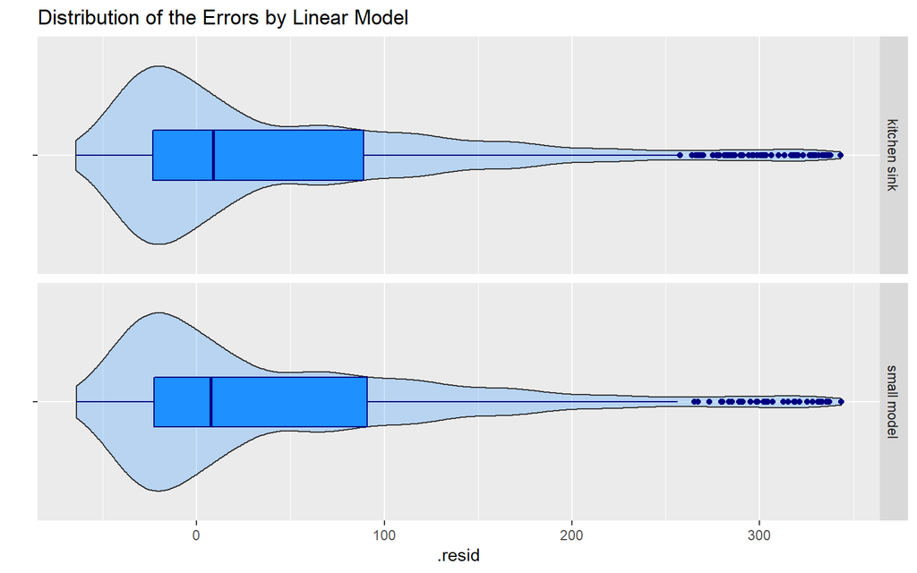

```r
ggplot(test_comp, aes(x = "", y = .resid)) +
   geom_violin(fill = "dodgerblue", alpha = 0.25) +
  geom_boxplot(fill = "dodgerblue", col = "navy", width = 0.25) + coord_flip() + labs(x = "") +
  facet_grid (modelname ~ .) + labs(title = "Distribution of the Errors by Linear Model")
```

## 12.3 Form the table comparing the model predictions:

Below are the Mean Square Prediction Error and the Mean Absolute Prediction Error for both `model1_tf` and `modelsmall`. It would seem that `model1_tf` has a slightly lower MAPE, but `modelsmall` has slightly lower MSPE. `model1_tf` has lower max_error as well.

```r
test_comp %>%
  group_by(modelname) %>%
  summarize(n = n(),
            MAPE = mean(abs(.resid)),
            MSPE = mean(.resid^2),
            max_error = max(abs(.resid)))
```

| modelname | n | MAPE | MSPE | max_error |
| --- | --- | --- | --- | --- |
| kitchen sink | 1506 | 66.97990 | 10279.54 | 343.0955 |
| small model | 1506 | 67.08331 | 10277.04 | 343.5761 |

## 12.4 Identify the largest errors:

The largest error in the kitchen sink model was in subject 3385, with an observed value of Alcohol of 372. The model fitted value was 28.9 (The value of `.expfit`). The largest error in the small model was also subject 3385, with an observed value of Alcohol of 372. The model fitted value was 28.4 (also the value of `.expfit`). As seen below, the same subject was most poorly fit by each model.

```r
temp1 <- test_ksink %>%
  filter(abs(.resid) == max(abs(.resid)))
temp2 <- test_small %>%
  filter(abs(.resid) == max(abs(.resid)))
bind_rows(temp1, temp2)
```

| subj_id | modelname | Alcohol | .fitted | .resid | Sex | newEdu | ADWRAGE | Severity | .se.fit | .expfit |
| --- | --- | --- | --- | --- | --- | --- | --- | --- | --- | --- |
| 3385 | kitchen sink | 372 | 3.363996 | 343.0955 | Female | HS | 14 | Severe | 0.06134765 | 28.90448 |
| 3385 | small model | 372 | 3.347229 | 343.5761 | Female | HS | 14 | Severe | 0.05136618 | 28.42387 |

# 13 Step 9. Select the better model and apply it to the entire data set:

There does not seem to be a significant difference between the two models. I will therefore select the kitchen sink model, since it contains the predictors of interest for my research question.

```r
anova(model1_tf, modelsmall)
```

|  | Res.Df | RSS | Df | Sum of Sq | F | Pr(>F) |
| --- | --- | --- | --- | --- | --- | --- |
| 1 | 4508 | 9586.892 | NA | NA | NA | NA |
| 2 | 4512 | 9595.606 | -4 | -8.714513 | 1.024446 | 0.3930596 |

## 13.1 Fitting the Chosen Model to the Complete Data:

```r
model_final <- lm(log(Alcohol) ~  Sex + newEdu + ADWRAGE + Severity, data = nsduh2016_final)
summary(model_final)
```

```
Call:
lm(formula = log(Alcohol) ~ Sex + newEdu + ADWRAGE + Severity,
    data = nsduh2016_final)

Residuals:
    Min      1Q  Median      3Q     Max
-4.2144 -1.0501  0.2251  1.1885  2.8258

Coefficients:
                     Estimate Std. Error t value Pr(>|t|)
(Intercept)          3.681157   0.110192  33.407  < 2e-16 ***
SexFemale           -0.371968   0.039426  -9.434  < 2e-16 ***
newEduAD             0.201679   0.092685   2.176   0.0296 *
newEduBAU            0.516660   0.079528   6.497 8.87e-11 ***
newEduHS            -0.015103   0.082666  -0.183   0.8550
newEduDNCC           0.137721   0.079216   1.739   0.0822 .
ADWRAGE             -0.002766   0.001660  -1.667   0.0957 .
SeverityModerate     0.108275   0.081906   1.322   0.1862
SeveritySevere       0.077433   0.082066   0.944   0.3454
SeverityVery Severe -0.010281   0.088861  -0.116   0.9079
---
Signif. codes:  0 '***' 0.001 '**' 0.01 '*' 0.05 '.' 0.1 ' ' 1

Residual standard error: 1.46 on 6014 degrees of freedom
Multiple R-squared:  0.03449,   Adjusted R-squared:  0.03304
F-statistic: 23.87 on 9 and 6014 DF,  p-value: < 2.2e-16
```

## 13.2 Residual Plots for the Chosen Model in the Complete Data:

Unfortunately, we see violations of regression assumptions. We see a “Fan” pattern of our Residuals vs Fitted plot which might indicate non-Linearity. In addition to that, the Normal Q-Q plot shows that we have violated the normality assumption.

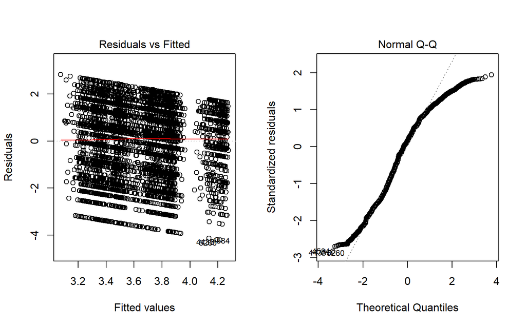

```r
par(mfrow = c(1,2))
plot(model_final, which = 1:2)
```

Joshua Wu

December 13th, 2018